# Case Study 2

Kenneth Poling

4/17/2020

## Introduction

The following project is designed to determine the explanatory variables with the greatest influence on Attrition and Monthly Income. I will determine correlation between the other vairables and my two response variables to determine which explanatory variables have the highest correlation. I will test KNN and Naive Bayes models to find the best solution for Attrition, and will use linear regression with Monthly Income.

A link to a YouTube version of this presentation can be found here: https://www.youtube.com/watch?v=TxFuFt4LnL8&feature=youtu.be&hd=1

## Executive Summary

I have been asked to provide the most common factors associated with attrition (voluntary departure form teh work force) at Frito Lay. Below I will demonstrate the correlation between attrition and job involvement, marital status, and overtime exemptions. These three, as you will see, are the variables with the highest correlation factor to attrition. I will also provide a couple of insights that may help you grow this business in the future.

```r
library(tidyverse)
library(Hmisc)
library(GGally)
CaseStudy2.data <- read.csv("CaseStudy2-data.csv")
   View(CaseStudy2.data)

summary(CaseStudy2.data)
```

```
##        ID             Age        Attrition           BusinessTravel
##  Min.   :  1.0   Min.   :18.00   No :730   Non-Travel       : 94
##  1st Qu.:218.2   1st Qu.:30.00   Yes:140   Travel_Frequently:158
##  Median :435.5   Median :35.00             Travel_Rarely    :618
##  Mean   :435.5   Mean   :36.83
##  3rd Qu.:652.8   3rd Qu.:43.00
##  Max.   :870.0   Max.   :60.00
##
##    DailyRate                       Department  DistanceFromHome   Education
##  Min.   : 103.0   Human Resources       : 35   Min.   : 1.000   Min.   :1.000
##  1st Qu.: 472.5   Research & Development:562   1st Qu.: 2.000   1st Qu.:2.000
##  Median : 817.5   Sales                 :273   Median : 7.000   Median :3.000
##  Mean   : 815.2                                Mean   : 9.339   Mean   :2.901
##  3rd Qu.:1165.8                                3rd Qu.:14.000   3rd Qu.:4.000
##  Max.   :1499.0                                Max.   :29.000   Max.   :5.000
##
##           EducationField EmployeeCount EmployeeNumber   EnvironmentSatisfaction
##  Human Resources : 15    Min.   :1     Min.   :   1.0   Min.   :1.000
##  Life Sciences   :358    1st Qu.:1     1st Qu.: 477.2   1st Qu.:2.000
##  Marketing       :100    Median :1     Median :1039.0   Median :3.000
##  Medical         :270    Mean   :1     Mean   :1029.8   Mean   :2.701
##  Other           : 52    3rd Qu.:1     3rd Qu.:1561.5   3rd Qu.:4.000
##  Technical Degree: 75    Max.   :1     Max.   :2064.0   Max.   :4.000
##
##     Gender      HourlyRate     JobInvolvement     JobLevel
##  Female:354   Min.   : 30.00   Min.   :1.000   Min.   :1.000
##  Male  :516   1st Qu.: 48.00   1st Qu.:2.000   1st Qu.:1.000
##               Median : 66.00   Median :3.000   Median :2.000
##               Mean   : 65.61   Mean   :2.723   Mean   :2.039
##               3rd Qu.: 83.00   3rd Qu.:3.000   3rd Qu.:3.000
##               Max.   :100.00   Max.   :4.000   Max.   :5.000
##
##                       JobRole    JobSatisfaction  MaritalStatus MonthlyIncome
##  Sales Executive          :200   Min.   :1.000   Divorced:191   Min.   : 1081
##  Research Scientist       :172   1st Qu.:2.000   Married :410   1st Qu.: 2840
##  Laboratory Technician    :153   Median :3.000   Single  :269   Median : 4946
##  Manufacturing Director   : 87   Mean   :2.709                  Mean   : 6390
##  Healthcare Representative: 76   3rd Qu.:4.000                  3rd Qu.: 8182
##  Sales Representative     : 53   Max.   :4.000                  Max.   :19999
##  (Other)                  :129
```

[output cut: 17 more lines]

```
##  Min.   : 0.00     Min.   :0.000         Min.   :1.000   Min.   : 0.000
##  1st Qu.: 6.00     1st Qu.:2.000         1st Qu.:2.000   1st Qu.: 3.000
##  Median :10.00     Median :3.000         Median :3.000   Median : 5.000
##  Mean   :11.05     Mean   :2.832         Mean   :2.782   Mean   : 6.962
##  3rd Qu.:15.00     3rd Qu.:3.000         3rd Qu.:3.000   3rd Qu.:10.000
##  Max.   :40.00     Max.   :6.000         Max.   :4.000   Max.   :40.000
##
##  YearsInCurrentRole YearsSinceLastPromotion YearsWithCurrManager
##  Min.   : 0.000     Min.   : 0.000          Min.   : 0.00
##  1st Qu.: 2.000     1st Qu.: 0.000          1st Qu.: 2.00
##  Median : 3.000     Median : 1.000          Median : 3.00
##  Mean   : 4.205     Mean   : 2.169          Mean   : 4.14
##  3rd Qu.: 7.000     3rd Qu.: 3.000          3rd Qu.: 7.00
##  Max.   :18.000     Max.   :15.000          Max.   :17.00
##
```

## Correlation

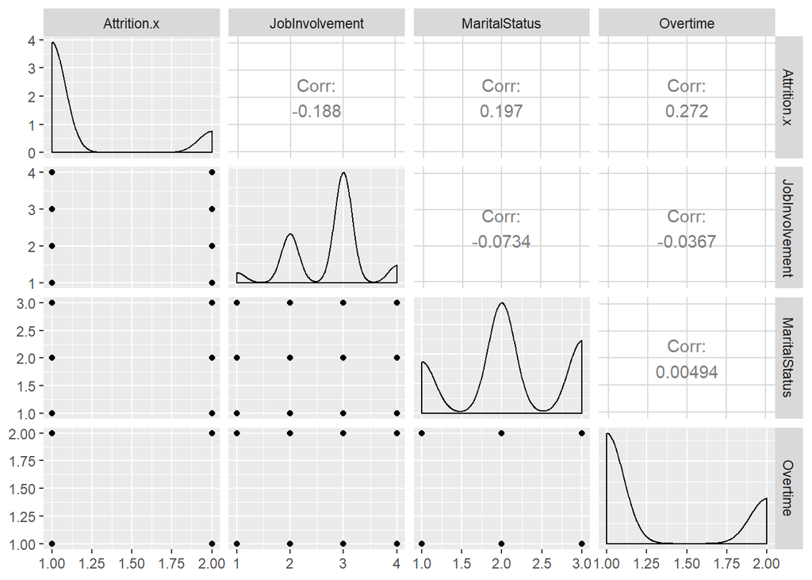

```r
CaseNum <- CaseStudy2.data %>% select(ID, Age, DailyRate, DistanceFromHome, Education, EmployeeCount, EmployeeNumber, EnvironmentSatisfaction, HourlyRate, JobInvolvement, JobLevel, JobSatisfaction, MonthlyIncome, MonthlyRate, NumCompaniesWorked, PercentSalaryHike, PerformanceRating, RelationshipSatisfaction, StandardHours, StockOptionLevel, TotalWorkingYears, TrainingTimesLastYear, WorkLifeBalance, YearsAtCompany,YearsInCurrentRole, YearsSinceLastPromotion, YearsWithCurrManager)
CaseNum <- CaseNum %>% mutate(Attrition = as.numeric(CaseStudy2.data$Attrition))

resNum <- rcorr(as.matrix(CaseNum))

CaseFact <- CaseStudy2.data %>% select(ID,MonthlyIncome,RelationshipSatisfaction)
CaseFact <- CaseFact %>% mutate(Attrition = as.numeric(CaseStudy2.data$Attrition),BusinessTravel = as.numeric(CaseStudy2.data$BusinessTravel),Department = as.numeric(CaseStudy2.data$Department),EducationField = as.numeric(CaseStudy2.data$EducationField),Gender = as.numeric(CaseStudy2.data$Gender),JobRole = as.numeric(CaseStudy2.data$JobRole),MaritalStatus = as.numeric(CaseStudy2.data$MaritalStatus),Over18 = as.numeric(CaseStudy2.data$Over18),Overtime = as.numeric(CaseStudy2.data$OverTime))

resFact <- rcorr(as.matrix(CaseFact))

#Narrowing it down
CaseMerge <- merge(CaseNum,CaseFact,by="ID")
caseFinal <- CaseMerge %>% select(Attrition.x, JobInvolvement, MaritalStatus, Overtime)
resFinal <- rcorr(as.matrix(caseFinal))
#Show Graphically
caseFinal %>% ggpairs()
```

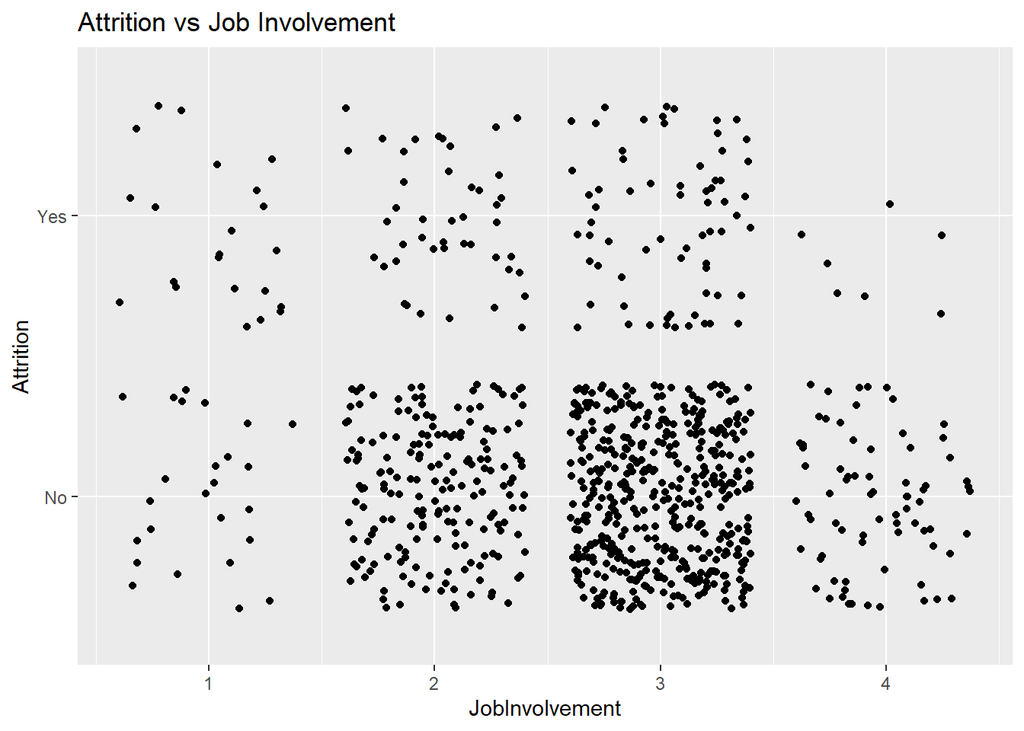

```r
CaseStudy2.data %>% ggplot(mapping = aes(x=JobInvolvement, y = Attrition )) + geom_point(position = "jitter") + ggtitle("Attrition vs Job Involvement")
```

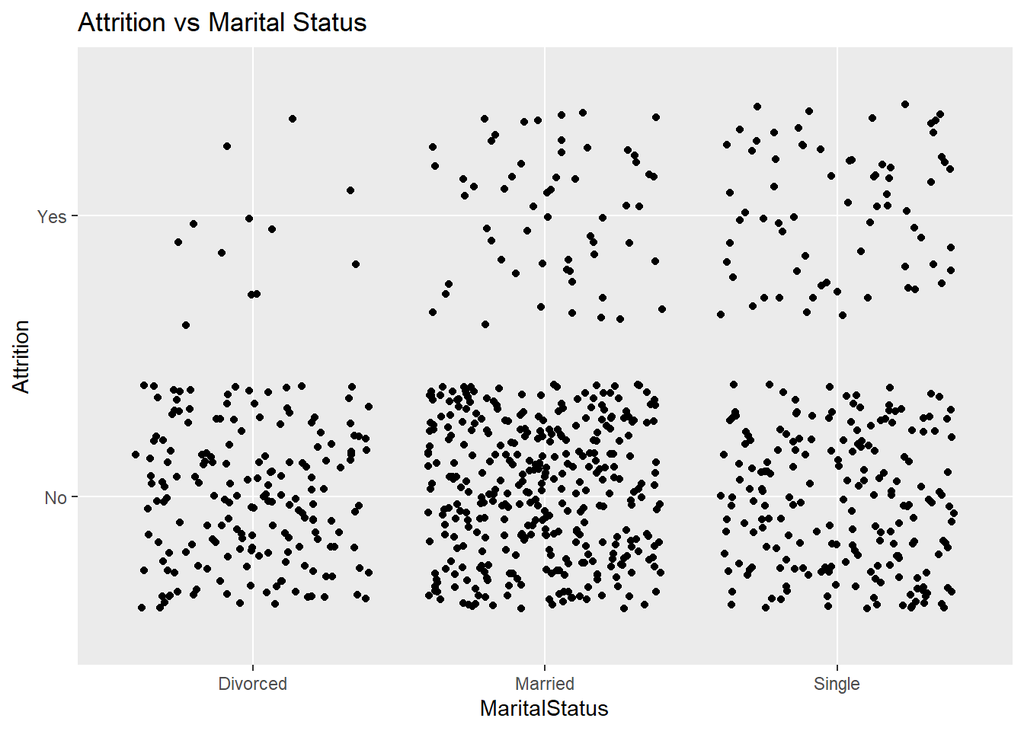

```r
CaseStudy2.data %>% ggplot(mapping = aes(x=MaritalStatus, y = Attrition )) + geom_point(position = "jitter") + ggtitle("Attrition vs Marital Status")
```

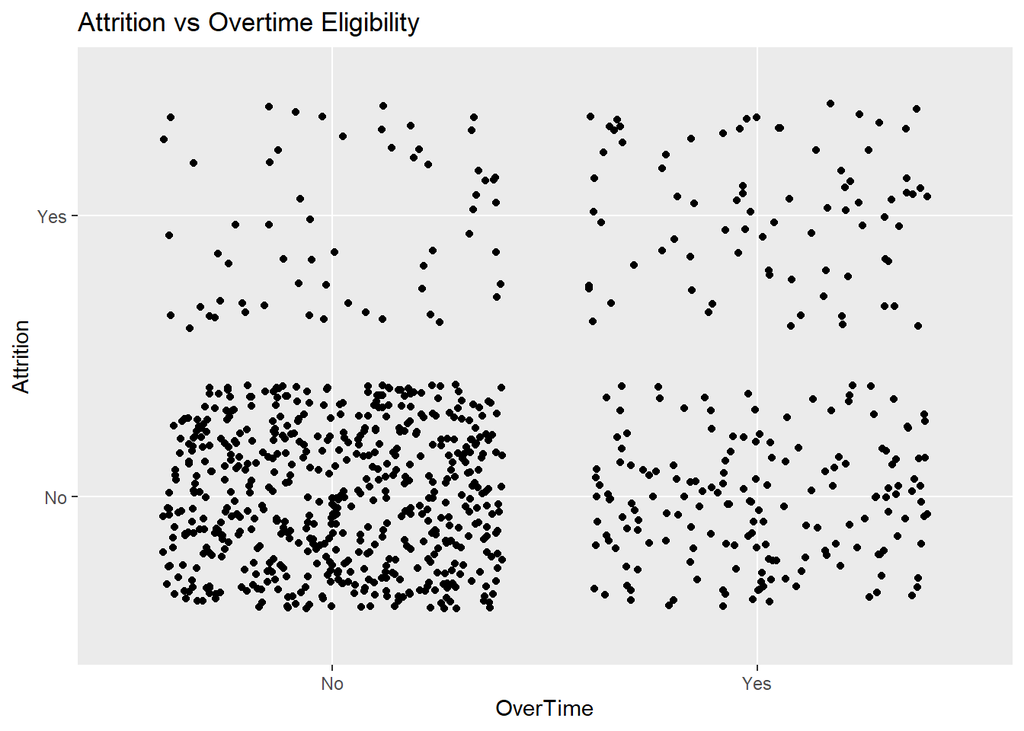

```r
CaseStudy2.data %>% ggplot(mapping = aes(x=OverTime, y = Attrition )) + geom_point(position = "jitter") + ggtitle("Attrition vs Overtime Eligibility")
```

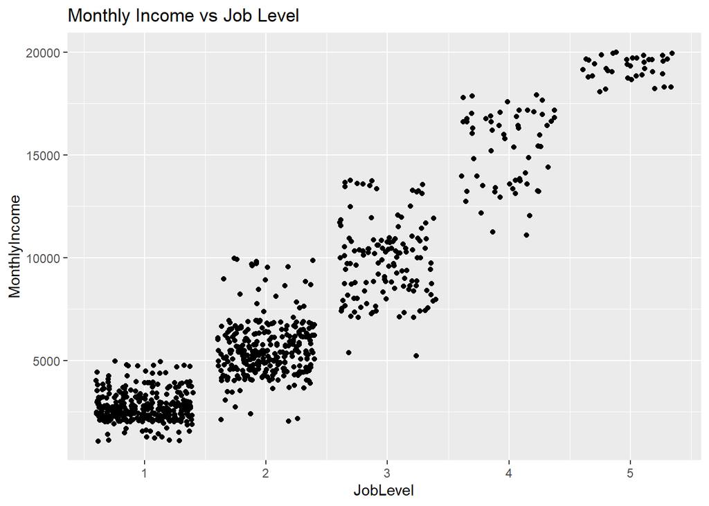

```r
CaseStudy2.data %>% ggplot(mapping = aes(x=JobLevel, y = MonthlyIncome )) + geom_point(position = "jitter") + ggtitle("Monthly Income vs Job Level")
```

##Notes

Overtime eligibility, Marital status, and job involvement appear to have the highest correletion to Attrition Rates. Job Involvement has a negative correleation. The more involved the worker is, the less attrition is likely. It seems that those who are divorced are less prone to attrition than married or single. Also, it appears that those not exempt from overtime are less likely to remain with the company.

Also, it appears that Job Level is closely correlated to Monthly Income, with an r of 0.95. This means that as Job level increases, salary is likely to increase.

```r
#KNN
library(class)
library(caret)
library(e1071)
```

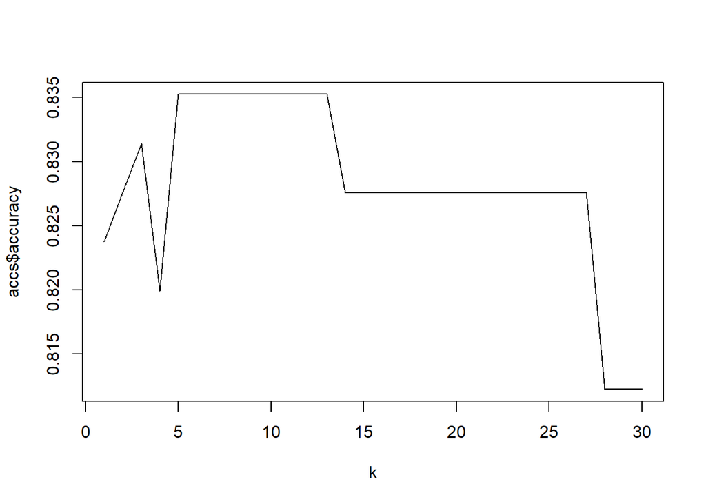

```r
trainIndices = sample(1:dim(CaseStudy2.data)[1],round(.7 * dim(CaseStudy2.data)[1]))
train = CaseStudy2.data[trainIndices,]
test = CaseStudy2.data[-trainIndices,]

train$Attrition = as.numeric(train$Attrition)
train$MaritalStatus = as.numeric(train$MaritalStatus)
train$OverTime = as.numeric(train$OverTime)
test$Attrition = as.numeric(test$Attrition)
test$MaritalStatus = as.numeric(test$MaritalStatus)
test$OverTime = as.numeric(test$OverTime)

accs = data.frame(accuracy = numeric(30), k = numeric(30))

for(i in 1:30)
{
   classifications = knn(train[,c(15,19,24)],test[,c(15,19,24)],train$Attrition, prob = TRUE, k = i)
   table(test$Attrition,classifications)
   CM = confusionMatrix(table(test$Attrition,classifications))
   accs$accuracy[i] = CM$overall[1]
   accs$k[i] = i
}

plot(accs$k,accs$accuracy, type = "l", xlab = "k")
```

```r
#Naive Bayes
CaseNB <- CaseStudy2.data %>% select(Attrition, JobInvolvement, MaritalStatus, OverTime)
trainIndices = sample(1:dim(CaseNB)[1],round(.7 * dim(CaseNB)[1]))
trainNB = CaseNB[trainIndices,]
testNB = CaseNB[-trainIndices,]
modelAtt = naiveBayes(trainNB[,c(2,3,4)],trainNB$Attrition)
table(predict(modelAtt,testNB[,c(2,3,4)]),testNB$Attrition)
```

```
##
##        No Yes
##   No  215  40
##   Yes   2   4
```

```r
CM = confusionMatrix(table(predict(modelAtt,testNB[,c(2,3,4)]),testNB$Attrition), positive = 'Yes')
```

##Notes

```r
fitMI = lm(MonthlyIncome~JobLevel+Age+YearsAtCompany, data = train)
summary(fitMI)
```

```
##
## Call:
## lm(formula = MonthlyIncome ~ JobLevel + Age + YearsAtCompany,
##     data = train)
##
## Residuals:
##     Min      1Q  Median      3Q     Max
## -5053.3  -964.9    96.7   752.0  3865.2
##
## Coefficients:
##                 Estimate Std. Error t value Pr(>|t|)
## (Intercept)    -2426.929    241.728 -10.040  < 2e-16 ***
## JobLevel        3981.823     64.416  61.814  < 2e-16 ***
## Age               19.146      7.212   2.655  0.00815 **
## YearsAtCompany    -3.213     10.912  -0.294  0.76851
## ---
## Signif. codes:  0 '***' 0.001 '**' 0.01 '*' 0.05 '.' 0.1 ' ' 1
##
## Residual standard error: 1398 on 605 degrees of freedom
## Multiple R-squared:   0.91,  Adjusted R-squared:  0.9095
## F-statistic:  2039 on 3 and 605 DF,  p-value: < 2.2e-16
```

##Predicting

To test the models for Attrition and Monthly Income, I will attempt to predict the values of each in the following two datasets:

CaseStudy2CompSet No Attrition.csv (NoAttr) CaseStudy2CompSet No Salary.csv” (NoSalary)

```r
NoAttr <- read.csv("CaseStudy2CompSet No Attrition.csv")
  View(NoAttr)
NoSalary <- read.csv("CaseStudy2CompSet No Salary.csv")
  View(NoSalary)

#Attrition Prediction
classificationsAtt = knn(train[,c(15,19,24)],test[,c(15,19,24)],train$Attrition, prob = TRUE, k = 20)
write.csv(classificationsAtt, "Case2PredictionsPoling Attrition.csv")

#Monthly Income Prediction
MIPred = predict(fitMI, newdata = NoSalary)
write.csv(MIPred, "Case2PredictionsPoling Salary.csv")
```